# LAB_10_24

2025-10-05

Hecho con gusto por Carla Carolina Pérez Hernández (UAEH) Alumno: Luis Armando González Arellano

T1_04_REDES COMPLEJAS(1) - Visión de redes complejas - parte 1

Objetivo: Estimar el Maximum Spanning Tree -árbol de expansión máxima- (asegurar una visión clara del espacio-producto) Red troncal: Estructura general de la red: vamos a poder v. redes complejas

Regla 1: mantener n-1 conexiones como máximo Regla 2: Quitar las conexiones con el peso más bajo, nos vamos quedar con las del peso máximo (menos conexiones) Regla 3: No crear nodos aislados —————————————————————————————————— En este ejercicio vamos a: 1. Usar un matriz hipotetica de datos 2. Graficar sus próximos adyacentes #####

1)la visualización del espacio - producto sea una red conectada: evitar islas de productos aislados. 2)PROBLEMA: tratar de visualizar demasiados enlaces puede crear una complejidad visual innecesaria donde se obstruirán las conexiones más relevantes. calculamos el árbol de expansión máxima (MST) de la matriz de proximidad. MST es el conjunto de enlaces que conecta todos los nodos de la red utilizando un número mínimo de conexiones y la suma máxima posible de proximidades. Calculamos el MST usando el algoritmo de Kruskal: Básicamente, el algoritmo clasifica los valores de la matriz de proximidad en orden descendente y luego incluye enlaces en el MST si y solo si conectan un producto aislado. Por definición, el MST incluye todos los productos, pero el número de enlaces es el mínimo posible. Después de seleccionar los enlaces utilizando los criterios mencionados anteriormente,construimos una visualización utilizando un algoritmo de diseño dirigido por la fuerza.

crear una matriz aleatoria de 200*200

```r
M <- matrix(runif(200*200, min=0, max=200), ncol=200)
diag (M) <-0
head (M [,1:6])
```

```
##            [,1]      [,2]       [,3]       [,4]      [,5]      [,6]
## [1,]   0.000000 173.90556 144.881559 148.163792  95.11526  56.10137
## [2,] 135.582070   0.00000   5.014418 165.697056 189.24522 198.85030
## [3,]   3.177223  91.43372   0.000000  93.243359 104.00381 156.61178
## [4,]  96.276586  58.19822 134.880999   0.000000  30.00684  41.27132
## [5,] 133.466029 126.37603 183.666164   6.942432   0.00000  68.91695
## [6,]  32.606857  80.68070 106.880874 163.192889 121.39477   0.00000
```

Para visualizar las dimensiones

```r
dim (M)
```

```
## [1] 200 200
```

grafica la matriz

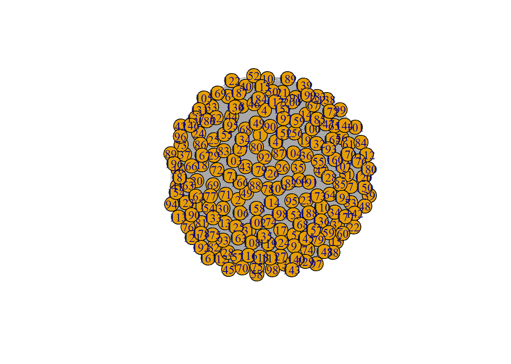

```r
library(igraph)
g<- graph.adjacency(M, mode="undirected", weighted="true")
plot(g)
```

Convertir la matriz en negativa

```r
M<- -M
```

Calcular la matriz de adyacencias

```r
g<- graph.adjacency(M, mode="undirected", weighted="true")
```

Calulcar el MST

```r
MST <- minimum.spanning.tree(g)
MST <-mst(g)
```

grafica nueva con matriz negativa, ver el espacio-producto, tecnológico

[figure not shown]

```r
plot (MST, vertex.shape="none", vertex.label.cex=7)
```

matriz de adyacencias (nuevo relacionamiento)

```r
A<- get.adjacency(MST, sparse= F)
```

Exportar resultados

```r
write.graph(MST,file= "g.gml", format="gml")
write.csv(A,file="adyacentes.csv")
```